# ST558_Homework_10_Group

# Introduction

In this assignment, we continue analyzing the Seoul Bike Sharing Demand dataset using the data preparation and exploratory analysis from Homework 9. We will use the tidymodels framework to compare multiple linear regression models, a regression tree, bagged trees, and a random forest. We will use cross-validation on the training data to select models and tuning parameters, then compare the selected models on a held-out test set using root mean squared error (RMSE) and mean absolute error (MAE).

## Reading the data

The first thing we’ll do is read the provided data into a tibble.

```r
# Load packages for data preparation, visualization, and modeling
library(lubridate)
library(tidyverse)
library(ggplot2)
library(tidymodels)

#Create data tibble

bike_demand<-read_csv("data/SeoulBikeData.csv",locale=locale(encoding="latin1"))
```

Note that the `locale=locale(encoding="latin1")` argument (used to fix the error mentioned in the assignment document) was found on Stack Overflow, via Google.

# EDA

## Checking the Data

### 1.

Now that we have a tibble, the next thing we’ll do is check to see if there are any missing data. To do that, we visually inspect all 8,760 rows of the tibble. Just kidding, we’ll use the `is.na()` function to check that and then sum it by column, to see how many missing values we are dealing with.

```r
# Look for missing data

colSums(is.na(bike_demand))
```

```
                     Date         Rented Bike Count                      Hour
                        0                         0                         0
          Temperature(°C)               Humidity(%)          Wind speed (m/s)
                        0                         0                         0
         Visibility (10m) Dew point temperature(°C)   Solar Radiation (MJ/m2)
                        0                         0                         0
             Rainfall(mm)             Snowfall (cm)                   Seasons
                        0                         0                         0
                  Holiday           Functioning Day
                        0                         0
```

Zero’s across the board, which is great!

### 2.

Next up, I’ll check all the columns and basic summary stats to make sure everything is making sense.

```r
# Look at raw tibble

bike_demand
```

```
# A tibble: 8,760 × 14
   Date       `Rented Bike Count`  Hour `Temperature(°C)` `Humidity(%)`
   <chr>                    <dbl> <dbl>             <dbl>         <dbl>
 1 01/12/2017                 254     0              -5.2            37
 2 01/12/2017                 204     1              -5.5            38
 3 01/12/2017                 173     2              -6              39
 4 01/12/2017                 107     3              -6.2            40
 5 01/12/2017                  78     4              -6              36
 6 01/12/2017                 100     5              -6.4            37
 7 01/12/2017                 181     6              -6.6            35
 8 01/12/2017                 460     7              -7.4            38
 9 01/12/2017                 930     8              -7.6            37
10 01/12/2017                 490     9              -6.5            27
# ℹ 8,750 more rows
# ℹ 9 more variables: `Wind speed (m/s)` <dbl>, `Visibility (10m)` <dbl>,
#   `Dew point temperature(°C)` <dbl>, `Solar Radiation (MJ/m2)` <dbl>,
#   `Rainfall(mm)` <dbl>, `Snowfall (cm)` <dbl>, Seasons <chr>, Holiday <chr>,
#   `Functioning Day` <chr>
```

Here, we see the following columns with character data: `Date`, `Seasons`, `Holiday`, and `Functioning day` and the following columns featuring numeric (double) data: `Rented Bike Count`, `Hour`, `Temperature(°C)`, `Humidity(%)`, `Wind speed (m/s)`, `Visibility (10m)`, `Dew point temperature(°C)`, `Solar Radiation (MJ/m2)`, `Rainfall(mm)`, and `Snowfall (cm)`. Of these, one might argue that `Hour` should be converted because it’s a time. However, it’s useful to leave it as is because it’s measuring the time that’s elapsed since the beginning of the day.

To make sure the data themselves are reasonable, a good place to start is basic summary statistics:

```r
# verify the data pass the smell test

summary(bike_demand)
```

```
     Date           Rented Bike Count      Hour       Temperature(°C)
 Length:8760        Min.   :   0.0    Min.   : 0.00   Min.   :-17.80
 Class :character   1st Qu.: 191.0    1st Qu.: 5.75   1st Qu.:  3.50
 Mode  :character   Median : 504.5    Median :11.50   Median : 13.70
                    Mean   : 704.6    Mean   :11.50   Mean   : 12.88
                    3rd Qu.:1065.2    3rd Qu.:17.25   3rd Qu.: 22.50
                    Max.   :3556.0    Max.   :23.00   Max.   : 39.40
  Humidity(%)    Wind speed (m/s) Visibility (10m) Dew point temperature(°C)
 Min.   : 0.00   Min.   :0.000    Min.   :  27     Min.   :-30.600
 1st Qu.:42.00   1st Qu.:0.900    1st Qu.: 940     1st Qu.: -4.700
 Median :57.00   Median :1.500    Median :1698     Median :  5.100
 Mean   :58.23   Mean   :1.725    Mean   :1437     Mean   :  4.074
 3rd Qu.:74.00   3rd Qu.:2.300    3rd Qu.:2000     3rd Qu.: 14.800
 Max.   :98.00   Max.   :7.400    Max.   :2000     Max.   : 27.200
 Solar Radiation (MJ/m2)  Rainfall(mm)     Snowfall (cm)       Seasons
 Min.   :0.0000          Min.   : 0.0000   Min.   :0.00000   Length:8760
 1st Qu.:0.0000          1st Qu.: 0.0000   1st Qu.:0.00000   Class :character
 Median :0.0100          Median : 0.0000   Median :0.00000   Mode  :character
 Mean   :0.5691          Mean   : 0.1487   Mean   :0.07507
 3rd Qu.:0.9300          3rd Qu.: 0.0000   3rd Qu.:0.00000
 Max.   :3.5200          Max.   :35.0000   Max.   :8.80000
   Holiday          Functioning Day
 Length:8760        Length:8760
 Class :character   Class :character
 Mode  :character   Mode  :character
```

Looking closely at the numeric variables here, nothing stands out as unreasonable.

### 3.

Next up, we’ll use the `lubridate` package to convert our first column to an actual date. Note that the `Date` column gives day, then month, then year.

**Note** I’ve changed the name of the tibble at this point, so we can call the unchanged (`bike_demand`) tibble later, if necessary.

```r
# Turn first column into date data type

demand_data<-bike_demand|>
  mutate(Date = dmy(Date))

demand_data
```

```
# A tibble: 8,760 × 14
   Date       `Rented Bike Count`  Hour `Temperature(°C)` `Humidity(%)`
   <date>                   <dbl> <dbl>             <dbl>         <dbl>
 1 2017-12-01                 254     0              -5.2            37
 2 2017-12-01                 204     1              -5.5            38
 3 2017-12-01                 173     2              -6              39
 4 2017-12-01                 107     3              -6.2            40
 5 2017-12-01                  78     4              -6              36
 6 2017-12-01                 100     5              -6.4            37
 7 2017-12-01                 181     6              -6.6            35
 8 2017-12-01                 460     7              -7.4            38
 9 2017-12-01                 930     8              -7.6            37
10 2017-12-01                 490     9              -6.5            27
# ℹ 8,750 more rows
# ℹ 9 more variables: `Wind speed (m/s)` <dbl>, `Visibility (10m)` <dbl>,
#   `Dew point temperature(°C)` <dbl>, `Solar Radiation (MJ/m2)` <dbl>,
#   `Rainfall(mm)` <dbl>, `Snowfall (cm)` <dbl>, Seasons <chr>, Holiday <chr>,
#   `Functioning Day` <chr>
```

Now, just to be sure nothing got messed up too badly:

```r
# Check for new date column missing data

sum(is.na(demand_data$Date))
```

```
[1] 0
```

### 4.

Next up, we’ll turn the character variables in `Seasons`, `Holiday`, and `Functioning Day` into factors. To begin, I’d like to look at what character strings are showing up because, in particular, I’m not sure what `Functioning Day` is all about.

```r
#Retrieve observations

unique(demand_data$Seasons)
```

```
[1] "Winter" "Spring" "Summer" "Autumn"
```

```r
unique(demand_data$Holiday)
```

```
[1] "No Holiday" "Holiday"
```

```r
unique(demand_data$`Functioning Day`)
```

```
[1] "Yes" "No"
```

The strings in the first two columns make sense to me. Looking through the tibble above, I’m only seeing `Yes`, which makes me think that maybe that column is recording whether the bike being rented is functional that day. If so, it would make sense that there aren’t any `No` entries, as there wouldn’t have been a bike rented if it weren’t functioning. Let’s check to see if, in fact, there are no `No`’s.

```r
# Check to see if "No" exists

sum(demand_data$'Functioning Day' == "No")
```

```
[1] 295
```

Well, I was wrong. There are some entries where the bike wasn’t functional. Looking more closely at the information provided in the link, it says `Functional Day - NoFunc(Non Functional Hours), Fun(Functional hours)`. Maybe looking at only the entries where there is a `No` there might give a clue.

```r
#Look more closely where Functioning Day = "No"

filter(demand_data,`Functioning Day`== "No")
```

```
# A tibble: 295 × 14
   Date       `Rented Bike Count`  Hour `Temperature(°C)` `Humidity(%)`
   <date>                   <dbl> <dbl>             <dbl>         <dbl>
 1 2018-04-11                   0     0              14.4            82
 2 2018-04-11                   0     1              13.6            81
 3 2018-04-11                   0     2              12.7            80
 4 2018-04-11                   0     3              11.6            81
 5 2018-04-11                   0     4              10.2            83
 6 2018-04-11                   0     5               9.7            84
 7 2018-04-11                   0     6               9              86
 8 2018-04-11                   0     7               8.8            85
 9 2018-04-11                   0     8               9.7            77
10 2018-04-11                   0     9              11.8            59
# ℹ 285 more rows
# ℹ 9 more variables: `Wind speed (m/s)` <dbl>, `Visibility (10m)` <dbl>,
#   `Dew point temperature(°C)` <dbl>, `Solar Radiation (MJ/m2)` <dbl>,
#   `Rainfall(mm)` <dbl>, `Snowfall (cm)` <dbl>, Seasons <chr>, Holiday <chr>,
#   `Functioning Day` <chr>
```

It looks like there weren’t any rentals when we had a `No` there. To confirm:

```r
# Confirm no rentals when Functioning Day = "No"

filter(demand_data,`Functioning Day`== "No") |> pull(`Rented Bike Count`)|>sum()
```

```
[1] 0
```

The nonfunctioning-hour records all have zero rentals. This indicates that the bike-sharing service was not functioning during those hours; it does not tell us whether anyone attempted to rent a bike.

With that in mind, we’ll next finish what we set out to do in this problem: create factors.

```r
# Create levels as appropriate

demand_data <- mutate(demand_data,
  SeasonsF = factor(Seasons, levels = c("Winter", "Spring", "Summer", "Autumn")),
  HolidayF = factor(Holiday, levels = c("No Holiday", "Holiday")),
  FunctioningF = factor(`Functioning Day`, levels = c("Yes", "No"))
)

demand_data
```

```
# A tibble: 8,760 × 17
   Date       `Rented Bike Count`  Hour `Temperature(°C)` `Humidity(%)`
   <date>                   <dbl> <dbl>             <dbl>         <dbl>
 1 2017-12-01                 254     0              -5.2            37
 2 2017-12-01                 204     1              -5.5            38
 3 2017-12-01                 173     2              -6              39
 4 2017-12-01                 107     3              -6.2            40
 5 2017-12-01                  78     4              -6              36
 6 2017-12-01                 100     5              -6.4            37
 7 2017-12-01                 181     6              -6.6            35
 8 2017-12-01                 460     7              -7.4            38
 9 2017-12-01                 930     8              -7.6            37
10 2017-12-01                 490     9              -6.5            27
# ℹ 8,750 more rows
# ℹ 12 more variables: `Wind speed (m/s)` <dbl>, `Visibility (10m)` <dbl>,
#   `Dew point temperature(°C)` <dbl>, `Solar Radiation (MJ/m2)` <dbl>,
#   `Rainfall(mm)` <dbl>, `Snowfall (cm)` <dbl>, Seasons <chr>, Holiday <chr>,
#   `Functioning Day` <chr>, SeasonsF <fct>, HolidayF <fct>, FunctioningF <fct>
```

### 5.

Next up, we’ll rename the columns so they’re a bit friendlier (and all lower case). Note that I’ll rename the factorized columns with lower case (sans `F`) for simplicity and tack on `_old` to the columns we no longer want to use.

```r
# Rename columns

demand_data <- demand_data |>
  rename(
    date = 1,
    bike_count = 2,
    hour = 3,
    temp = 4,
    humidity = 5,
    wind_speed = 6,
    visibility = 7,
    dew_pt = 8,
    solar_rad = 9,
    rainfall = 10,
    snowfall = 11,
    Seasons_old = 12,
    Holiday_old = 13,
    Functioning_old = 14,
    seasons = 15,
    holiday = 16,
    functioning = 17
  )

demand_data
```

```
# A tibble: 8,760 × 17
   date       bike_count  hour  temp humidity wind_speed visibility dew_pt
   <date>          <dbl> <dbl> <dbl>    <dbl>      <dbl>      <dbl>  <dbl>
 1 2017-12-01        254     0  -5.2       37        2.2       2000  -17.6
 2 2017-12-01        204     1  -5.5       38        0.8       2000  -17.6
 3 2017-12-01        173     2  -6         39        1         2000  -17.7
 4 2017-12-01        107     3  -6.2       40        0.9       2000  -17.6
 5 2017-12-01         78     4  -6         36        2.3       2000  -18.6
 6 2017-12-01        100     5  -6.4       37        1.5       2000  -18.7
 7 2017-12-01        181     6  -6.6       35        1.3       2000  -19.5
 8 2017-12-01        460     7  -7.4       38        0.9       2000  -19.3
 9 2017-12-01        930     8  -7.6       37        1.1       2000  -19.8
10 2017-12-01        490     9  -6.5       27        0.5       1928  -22.4
# ℹ 8,750 more rows
# ℹ 9 more variables: solar_rad <dbl>, rainfall <dbl>, snowfall <dbl>,
#   Seasons_old <chr>, Holiday_old <chr>, Functioning_old <chr>, seasons <fct>,
#   holiday <fct>, functioning <fct>
```

### 6.

For this part, we’ll create summary tables. To begin, we’ll do a basic summary across the numeric variables. Recall that, earlier, we noticed that the tibble records whether the bike was functioning. So, in the summary below, I’m going to subset on times when the bike was functioning.

```r
# Five +1 number summaries across numeric data

six_num_sum <- apply(X = demand_data |>
                       filter(functioning == "Yes")|>
                        select(where(is.numeric)),
                      MARGIN = 2,
                      FUN = summary
                      )
six_num_sum
```

```
        bike_count     hour      temp humidity wind_speed visibility     dew_pt
Min.         2.000  0.00000 -17.80000  0.00000   0.000000     27.000 -30.600000
1st Qu.    214.000  6.00000   3.00000 42.00000   0.900000    935.000  -5.100000
Median     542.000 12.00000  13.50000 57.00000   1.500000   1690.000   4.700000
Mean       729.157 11.50703  12.77106 58.14719   1.725883   1433.873   3.944997
3rd Qu.   1084.000 18.00000  22.70000 74.00000   2.300000   2000.000  15.200000
Max.      3556.000 23.00000  39.40000 98.00000   7.400000   2000.000  27.200000
        solar_rad   rainfall   snowfall
Min.    0.0000000  0.0000000 0.00000000
1st Qu. 0.0000000  0.0000000 0.00000000
Median  0.0100000  0.0000000 0.00000000
Mean    0.5678677  0.1491199 0.07768458
3rd Qu. 0.9300000  0.0000000 0.00000000
Max.    3.5200000 35.0000000 8.80000000
```

Next up, let’s look at some one way tables based on categorical variables.

```r
# One way tables
one_way <- list(
  seasons_summary = demand_data |> group_by(seasons) |> summarize(count = n()),
  holiday_summary = demand_data |> group_by(holiday) |> summarize(count = n()),
  functioning_summary = demand_data |> group_by(functioning) |> summarize(count = n())
)

one_way
```

```
$seasons_summary
# A tibble: 4 × 2
  seasons count
  <fct>   <int>
1 Winter   2160
2 Spring   2208
3 Summer   2208
4 Autumn   2184

$holiday_summary
# A tibble: 2 × 2
  holiday    count
  <fct>      <int>
1 No Holiday  8328
2 Holiday      432

$functioning_summary
# A tibble: 2 × 2
  functioning count
  <fct>       <int>
1 Yes          8465
2 No            295
```

Next, we compare bike rental counts between functioning and nonfunctioning hours. This helps us decide which observations to retain for our analysis.

```r
# Summarize hourly rentals by functioning status
demand_data |>
  group_by(functioning) |>
  summarize(
    hours = n(),
    mean_rentals = mean(bike_count),
    median_rentals = median(bike_count),
    sd_rentals = sd(bike_count),
    min_rentals = min(bike_count),
    max_rentals = max(bike_count)
  )
```

```
# A tibble: 2 × 7
  functioning hours mean_rentals median_rentals sd_rentals min_rentals
  <fct>       <int>        <dbl>          <dbl>      <dbl>       <dbl>
1 Yes          8465         729.            542       642.           2
2 No            295           0               0         0            0
# ℹ 1 more variable: max_rentals <dbl>
```

Nonfunctioning hours have zero recorded rentals. We exclude these hours so that the remaining analysis describes bike rental demand while the service was functioning.

```r
# Retain functioning hours for the remaining analysis
demand_data <- demand_data |>
  filter(functioning == "Yes")

# Check the number of retained rows
nrow(demand_data)
```

```
[1] 8465
```

Using the functioning hours, we next compare hourly bike rental counts across seasons.

```r
# Summarize hourly rentals within each season
demand_data |>
  group_by(seasons) |>
  summarize(
    hours = n(),
    mean_rentals = mean(bike_count),
    median_rentals = median(bike_count),
    sd_rentals = sd(bike_count),
    min_rentals = min(bike_count),
    max_rentals = max(bike_count)
  )
```

```
# A tibble: 4 × 7
  seasons hours mean_rentals median_rentals sd_rentals min_rentals max_rentals
  <fct>   <int>        <dbl>          <dbl>      <dbl>       <dbl>       <dbl>
1 Winter   2160         226.           203        150.           3         937
2 Spring   2160         746.           599        619.           2        3251
3 Summer   2208        1034.           906.       690.           9        3556
4 Autumn   1937         924.           856        618.           2        3298
```

Summer had the highest average hourly bike rental count, at approximately 1,034 rentals, followed by autumn at 924 and spring at 746. Winter had the lowest average, at approximately 226 rentals per hour. The medians followed the same seasonal pattern. Hourly rental counts also varied more in summer, which had the largest standard deviation at approximately 690 rentals, compared with approximately 150 in winter. These summaries suggest that rental demand differs across seasons, although they do not account for other factors such as weather.

We also compare hourly rental counts between holidays and nonholidays.

```r
# Summarize hourly rentals by holiday status
demand_data |>
  group_by(holiday) |>
  summarize(
    hours = n(),
    mean_rentals = mean(bike_count),
    median_rentals = median(bike_count),
    sd_rentals = sd(bike_count),
    min_rentals = min(bike_count),
    max_rentals = max(bike_count)
  )
```

```
# A tibble: 2 × 7
  holiday   hours mean_rentals median_rentals sd_rentals min_rentals max_rentals
  <fct>     <int>        <dbl>          <dbl>      <dbl>       <dbl>       <dbl>
1 No Holid…  8057         739.            561       644.           2        3556
2 Holiday     408         529.            259       574.           3        2400
```

Nonholidays had a higher average hourly rental count than holidays: approximately 739 versus 529 rentals. The median was also higher on nonholidays, at 561 compared with 259 on holidays. Rental counts showed somewhat greater variability on nonholidays, with a standard deviation of approximately 644 compared with 574 on holidays. We compare averages rather than total rentals because the dataset contains many more functioning hours on nonholidays than on holidays. These are descriptive comparisons and do not establish that holiday status causes the difference in rental demand.

So far, each observation represents one functioning hour. Next, we will summarize the data by date, season, and holiday status so that each retained day has one observation for the remaining analysis.

### 7.

Next, we combine the hourly observations into daily summaries. We group by date, season, and holiday status, then calculate daily totals for bike rentals, rainfall, and snowfall. For the remaining weather variables, we calculate daily averages. These summaries use the functioning hours retained in the previous step.

```r
# Combine the retained hourly observations into daily summaries
daily_demand <- demand_data |>
  group_by(date, seasons, holiday) |>
  summarize(
    bike_count = sum(bike_count),
    rainfall = sum(rainfall),
    snowfall = sum(snowfall),
    temp = mean(temp),
    humidity = mean(humidity),
    wind_speed = mean(wind_speed),
    visibility = mean(visibility),
    dew_pt = mean(dew_pt),
    solar_rad = mean(solar_rad),
    .groups = "drop"
  )

# View the daily dataset
daily_demand
```

```
# A tibble: 353 × 12
   date       seasons holiday    bike_count rainfall snowfall    temp humidity
   <date>     <fct>   <fct>           <dbl>    <dbl>    <dbl>   <dbl>    <dbl>
 1 2017-12-01 Winter  No Holiday       9539      0        0   -2.45       45.9
 2 2017-12-02 Winter  No Holiday       8523      0        0    1.32       62.0
 3 2017-12-03 Winter  No Holiday       7222      4        0    4.88       81.5
 4 2017-12-04 Winter  No Holiday       8729      0.1      0   -0.304      52.5
 5 2017-12-05 Winter  No Holiday       8307      0        0   -4.46       36.4
 6 2017-12-06 Winter  No Holiday       6669      1.3      8.6  0.0458     70.8
 7 2017-12-07 Winter  No Holiday       8549      0       10.4  1.09       67.5
 8 2017-12-08 Winter  No Holiday       8032      0        0   -3.82       41.8
 9 2017-12-09 Winter  No Holiday       7233      0        0   -0.846      46
10 2017-12-10 Winter  No Holiday       3453      4.1     32.5  1.19       69.7
# ℹ 343 more rows
# ℹ 4 more variables: wind_speed <dbl>, visibility <dbl>, dew_pt <dbl>,
#   solar_rad <dbl>
```

### 8.

Now that the data have been summarized by day, we revisit the numerical summaries. The bike rental count now represents the total rentals during each day’s retained functioning hours. Rainfall and snowfall are summed across those hours, while the other weather variables represent averages.

```r
# Summarize the numeric variables in the daily dataset
daily_summary <- apply(
  X = daily_demand |>
    select(where(is.numeric)),
  MARGIN = 2,
  FUN = summary
)

daily_summary
```

```
        bike_count  rainfall snowfall       temp humidity wind_speed visibility
Min.        977.00  0.000000  0.00000 -14.737500 22.25000   0.662500   214.2917
1st Qu.    6967.00  0.000000  0.00000   3.304167 47.58333   1.304167  1087.0417
Median    18563.00  0.000000  0.00000  13.737500 57.16667   1.658333  1557.7500
Mean      17485.31  3.575921  1.86289  12.775844 58.16627   1.726148  1434.0137
3rd Qu.   26285.00  0.500000  0.00000  22.591667 67.70833   1.954167  1874.2917
Max.      36149.00 95.500000 78.70000  33.741667 95.87500   4.000000  2000.0000
            dew_pt  solar_rad
Min.    -27.750000 0.02916667
1st Qu.  -5.187500 0.28333333
Median    4.612500 0.56500000
Mean      3.954165 0.56773191
3rd Qu.  14.920833 0.82000000
Max.     25.037500 1.21666667
```

Daily bike rental totals ranged from 977 to 36,149, with an average of approximately 17,485 and a median of 18,563. The middle 50% of daily totals fell between 6,967 and 26,285, showing substantial variation across days. Average daily temperature also varied considerably, ranging from approximately −14.7°C to 33.7°C. Rainfall and snowfall summaries contained many zeros, indicating that precipitation was absent on many of the retained days.

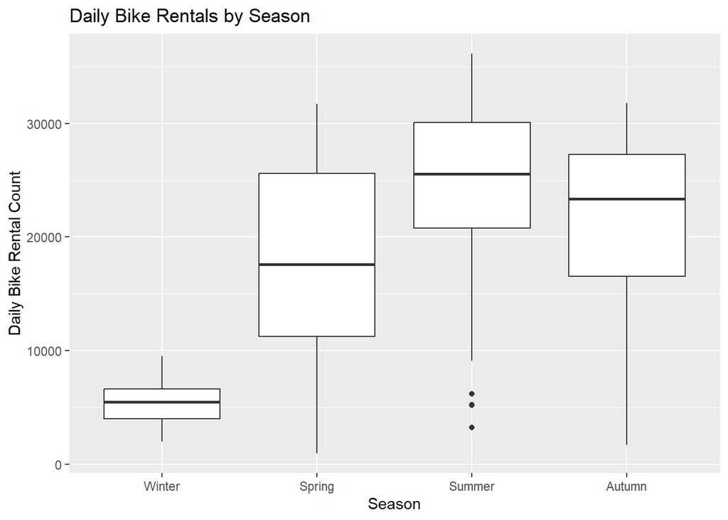

```r
# Compare the distribution of daily rentals across seasons
ggplot(
  data = daily_demand,
  mapping = aes(x = seasons, y = bike_count)
) +
  geom_boxplot() +
  labs(
    title = "Daily Bike Rentals by Season",
    x = "Season",
    y = "Daily Bike Rental Count"
  )
```

Daily bike rental counts differed across seasons. Summer had the highest median daily rental count, followed by autumn, spring, and winter. Winter also had the smallest spread in the middle 50% of daily counts, while spring had the largest. Summer had three unusually low daily totals, shown as points below the lower whisker. These observations may warrant closer examination, but the plot alone does not establish why they were low.

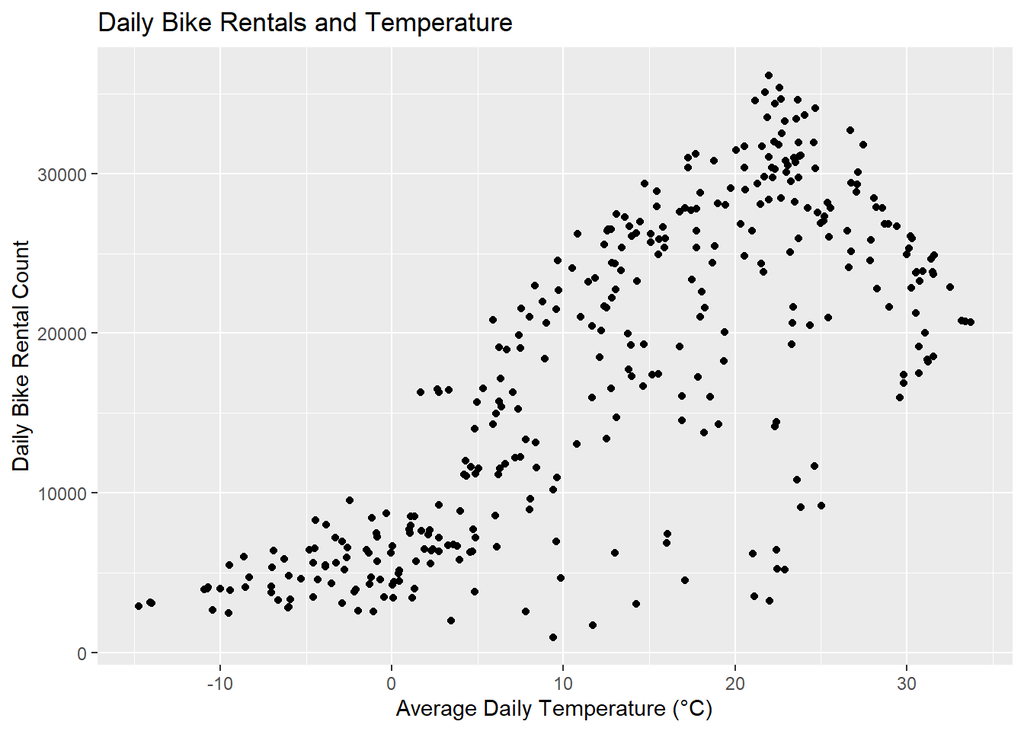

```r
# Explore daily rentals in relation to average temperature
ggplot(
  data = daily_demand,
  mapping = aes(x = temp, y = bike_count)
) +
  geom_point() +
  labs(
    title = "Daily Bike Rentals and Temperature",
    x = "Average Daily Temperature (°C)",
    y = "Daily Bike Rental Count"
  )
```

Daily bike rentals generally increased with average daily temperature, although the relationship appears curved rather than perfectly straight. Rental counts were generally highest around 20–25°C and tended to decrease at higher temperatures. There was also considerable variation among days with similar temperatures, suggesting that temperature alone does not explain daily rental demand.

Next, we examine correlations among the daily numeric variables. These describe the direction and strength of pairwise linear relationships, including relationships between bike rental counts and weather variables. We also examine correlations among the weather variables because some predictors may contain similar information.

```r
# Select the numeric variables from the daily dataset
daily_numeric <- daily_demand |>
  select(where(is.numeric))

# Calculate Pearson correlations
daily_correlations <- cor(daily_numeric)

# Display correlations rounded to two decimal places
round(daily_correlations, digits = 2)
```

```
           bike_count rainfall snowfall  temp humidity wind_speed visibility
bike_count       1.00    -0.24    -0.27  0.75     0.04      -0.19       0.17
rainfall        -0.24     1.00    -0.02  0.14     0.53      -0.10      -0.22
snowfall        -0.27    -0.02     1.00 -0.27     0.07       0.02      -0.10
temp             0.75     0.14    -0.27  1.00     0.40      -0.26       0.00
humidity         0.04     0.53     0.07  0.40     1.00      -0.23      -0.56
wind_speed      -0.19    -0.10     0.02 -0.26    -0.23       1.00       0.21
visibility       0.17    -0.22    -0.10  0.00    -0.56       0.21       1.00
dew_pt           0.65     0.26    -0.21  0.96     0.63      -0.29      -0.15
solar_rad        0.74    -0.32    -0.23  0.55    -0.27       0.10       0.27
           dew_pt solar_rad
bike_count   0.65      0.74
rainfall     0.26     -0.32
snowfall    -0.21     -0.23
temp         0.96      0.55
humidity     0.63     -0.27
wind_speed  -0.29      0.10
visibility  -0.15      0.27
dew_pt       1.00      0.38
solar_rad    0.38      1.00
```

Daily bike rental counts had positive correlations with temperature (0.75), solar radiation (0.74), and dew point temperature (0.65). Correlations with rainfall (−0.24) and snowfall (−0.27) were negative but weaker. Humidity had little linear association with rental counts (0.04), although this does not rule out a curved relationship or an association after accounting for other variables. Temperature and dew point were very strongly correlated (0.96), suggesting that these predictors contain overlapping information. Including both in a regression model may make their individual coefficients harder to interpret.

# Split the Data

We randomly divide the daily data into approximately 75% training data and 25% test data, stratifying by season to maintain similar seasonal representation in both sets. We will use the training data for cross-validation and model selection, and reserve the test data for evaluating the selected models. A fixed random seed makes the split reproducible.

```r
# Make the random split reproducible
set.seed(558)

# Split the daily data into training and test sets
bike_split <- initial_split(
  daily_demand,
  prop = 0.75,
  strata = seasons
)

# Extract the two datasets
bike_train <- training(bike_split)
bike_test <- testing(bike_split)

# Check the number of days in each set
nrow(bike_train)
```

```
[1] 263
```

```r
nrow(bike_test)
```

```
[1] 90
```

```r
# Check seasonal representation
table(bike_train$seasons)
```

```
Winter Spring Summer Autumn
    67     67     69     60
```

```r
table(bike_test$seasons)
```

```
Winter Spring Summer Autumn
    23     23     23     21
```

## Create Cross-Validation Folds

We divide the training data into 10 folds for cross-validation. For each model, we will fit using nine folds and evaluate predictions on the remaining fold, repeating until each fold has been used for evaluation. We will use the same folds across models to make their performance comparisons consistent. The separate test dataset remains reserved for final evaluation.

```r
# Make the cross-validation folds reproducible
set.seed(558)

# Create 10 folds using only the training data
bike_folds <- vfold_cv(
  bike_train,
  v = 10
)

# View the cross-validation setup
bike_folds
```

```
#  10-fold cross-validation
# A tibble: 10 × 2
   splits           id
   <list>           <chr>
 1 <split [236/27]> Fold01
 2 <split [236/27]> Fold02
 3 <split [236/27]> Fold03
 4 <split [237/26]> Fold04
 5 <split [237/26]> Fold05
 6 <split [237/26]> Fold06
 7 <split [237/26]> Fold07
 8 <split [237/26]> Fold08
 9 <split [237/26]> Fold09
10 <split [237/26]> Fold10
```

# Fitting Multiple Linear Regression Models

## Recipe 1: Main Effects

Our first recipe prepares the predictors for a model containing main effects only. We use the date to create a weekday/weekend factor, then remove the original date and the intermediate day-of-week variable. We standardize the numeric weather predictors and create dummy variables for season, holiday status, and day type. The bike rental count remains in its original units.

```r
# Define the preprocessing steps for the first model
bike_recipe_1 <- recipe(
  bike_count ~ .,
  data = bike_train
) |>
  step_date(date, features = "dow", label = FALSE) |>
  step_mutate(
    day_type = factor(
      if_else(
        date_dow %in% c(1, 7),
        "weekend",
        "weekday"
      ),
      levels = c("weekday", "weekend")
    )
  ) |>
  step_rm(date, date_dow) |>
  step_normalize(all_numeric_predictors()) |>
  step_dummy(all_nominal_predictors())

# View the recipe
bike_recipe_1
```

```
── Recipe ──────────────────────────────────────────────────────────────────────
```

```
── Inputs
```

```
Number of variables by role
```

```
outcome:    1
predictor: 11
```

```
── Operations
```

```
• Date features from: date
```

```
• Variable mutation for: factor(if_else(date_dow %in% c(1, 7), "weekend",
  "weekday"), levels = c("weekday", "weekend"))
```

```
• Variables removed: date date_dow
```

```
• Centering and scaling for: all_numeric_predictors()
```

```
• Dummy variables from: all_nominal_predictors()
```

```r
# Prepare a separate copy of the recipe for inspection
recipe_1_check <- prep(
  bike_recipe_1,
  training = bike_train
)

# View the transformed training data
recipe_1_preview <- bake(
  recipe_1_check,
  new_data = NULL
)

glimpse(recipe_1_preview)
```

```
Rows: 263
Columns: 14
$ rainfall         <dbl> 2.6423390, -0.3141390, -0.1855965, -0.3141390, -0.314…
$ snowfall         <dbl> -0.1968451, -0.1968451, -0.1968451, -0.1968451, -0.19…
$ temp             <dbl> 0.938421099, 0.958649502, 0.813077244, 0.761783793, 0…
$ humidity         <dbl> 1.57005462, 0.22280176, -0.10097794, -0.68817165, -0.…
$ wind_speed       <dbl> -1.162611405, 1.325677533, 1.282528013, -0.450644339,…
$ visibility       <dbl> 0.19115716, 1.10083016, 0.88752811, 1.19058389, 1.170…
$ dew_pt           <dbl> 1.249448104, 0.883239897, 0.666932057, 0.452880781, 0…
$ solar_rad        <dbl> -1.34347502, 1.18971298, 0.80774536, 0.57829954, 0.91…
$ bike_count       <dbl> 10802, 31114, 30381, 31694, 31809, 30991, 28199, 1417…
$ seasons_Spring   <dbl> 0, 0, 0, 0, 0, 0, 0, 0, 0, 0, 0, 0, 0, 0, 0, 0, 0, 0,…
$ seasons_Summer   <dbl> 0, 0, 0, 0, 0, 0, 0, 0, 0, 0, 0, 0, 0, 0, 0, 0, 0, 0,…
$ seasons_Autumn   <dbl> 1, 1, 1, 1, 1, 1, 1, 1, 1, 1, 1, 1, 1, 1, 1, 1, 1, 1,…
$ holiday_Holiday  <dbl> 0, 0, 0, 0, 0, 0, 0, 0, 0, 0, 0, 1, 1, 0, 0, 0, 0, 0,…
$ day_type_weekend <dbl> 0, 0, 0, 0, 0, 0, 0, 1, 0, 0, 1, 1, 0, 0, 0, 0, 0, 1,…
```

```r
# Check that temperature was standardized
mean(recipe_1_preview$temp)
```

```
[1] 1.739464e-17
```

```r
sd(recipe_1_preview$temp)
```

```
[1] 1
```

```r
# Confirm the outcome remains unchanged
identical(
  recipe_1_preview$bike_count,
  bike_train$bike_count
)
```

```
[1] TRUE
```

## Recipe 2: Main Effects and Interactions

Our second recipe retains all preprocessing steps and predictors from Recipe 1, then adds interactions between season and holiday status, season and standardized temperature, and standardized temperature and rainfall. These terms allow the association of one predictor with rental counts to depend on another predictor.

The training data contain only one summer holiday. When that observation is held out in Fold06, the fitting data contain no summer holidays, making the summer-by-holiday interaction column entirely zero. We therefore remove constant predictors within each fold using step_zv(). For that fold, predictions use the remaining terms without a separate summer-specific holiday adjustment. This handles the unestimable term but does not resolve the limited information available for this combination.

```r
# Extend Recipe 1 with the required interactions
# Remove predictors that are constant within the fitting data
bike_recipe_2 <- bike_recipe_1 |>
  step_interact(
    terms = ~ starts_with("seasons_"):holiday_Holiday +
      starts_with("seasons_"):temp +
      temp:rainfall
  ) |>
  step_zv(all_predictors())

# View the recipe
bike_recipe_2
```

```
── Recipe ──────────────────────────────────────────────────────────────────────
```

```
── Inputs
```

```
Number of variables by role
```

```
outcome:    1
predictor: 11
```

```
── Operations
```

```
• Date features from: date
```

```
• Variable mutation for: factor(if_else(date_dow %in% c(1, 7), "weekend",
  "weekday"), levels = c("weekday", "weekend"))
```

```
• Variables removed: date date_dow
```

```
• Centering and scaling for: all_numeric_predictors()
```

```
• Dummy variables from: all_nominal_predictors()
```

```
• Interactions with: ...
```

```
• Zero variance filter on: all_predictors()
```

```r
# Prepare a separate copy for inspection
recipe_2_check <- prep(
  bike_recipe_2,
  training = bike_train
)

recipe_2_preview <- bake(
  recipe_2_check,
  new_data = NULL
)

# Check dimensions and interaction column names
dim(recipe_2_preview)
```

```
[1] 263  21
```

```r
names(recipe_2_preview |>
        select(contains("_x_")))
```

```
[1] "seasons_Spring_x_holiday_Holiday" "seasons_Summer_x_holiday_Holiday"
[3] "seasons_Autumn_x_holiday_Holiday" "seasons_Spring_x_temp"
[5] "seasons_Summer_x_temp"            "seasons_Autumn_x_temp"
[7] "temp_x_rainfall"
```

## Recipe 3: Interactions and Quadratic Terms

Our third recipe retains all predictors and interactions from Recipe 2 and adds squared terms for standardized temperature and humidity. These terms allow curved relationships with daily bike rental counts. We retain the original linear temperature and humidity terms alongside their squared versions.

```r
# Extend Recipe 2 with squared standardized predictors
bike_recipe_3 <- bike_recipe_2 |>
  step_mutate(
    temp_sq = temp^2,
    humidity_sq = humidity^2
  )

# View the recipe
bike_recipe_3
```

```
── Recipe ──────────────────────────────────────────────────────────────────────
```

```
── Inputs
```

```
Number of variables by role
```

```
outcome:    1
predictor: 11
```

```
── Operations
```

```
• Date features from: date
```

```
• Variable mutation for: factor(if_else(date_dow %in% c(1, 7), "weekend",
  "weekday"), levels = c("weekday", "weekend"))
```

```
• Variables removed: date date_dow
```

```
• Centering and scaling for: all_numeric_predictors()
```

```
• Dummy variables from: all_nominal_predictors()
```

```
• Interactions with: ...
```

```
• Zero variance filter on: all_predictors()
```

```
• Variable mutation for: temp^2 humidity^2
```

```r
# Prepare a separate copy for inspection
recipe_3_check <- prep(
  bike_recipe_3,
  training = bike_train
)

recipe_3_preview <- bake(
  recipe_3_check,
  new_data = NULL
)

# Check dimensions and the new squared terms
dim(recipe_3_preview)
```

```
[1] 263  23
```

```r
recipe_3_preview |>
  select(temp, temp_sq, humidity, humidity_sq) |>
  head()
```

```
# A tibble: 6 × 4
   temp temp_sq humidity humidity_sq
  <dbl>   <dbl>    <dbl>       <dbl>
1 0.938   0.881    1.57       2.47
2 0.959   0.919    0.223      0.0496
3 0.813   0.661   -0.101      0.0102
4 0.762   0.580   -0.688      0.474
5 0.845   0.714   -0.428      0.183
6 0.924   0.854    0.256      0.0654
```

## Linear Model Specification and Workflows

We specify a linear regression model using the `lm` engine. We then create three workflows, each pairing this model specification with a different recipe. This keeps the model-fitting method consistent while allowing us to compare main effects, interactions, and quadratic terms.

```r
# Specify linear regression using the lm engine
bike_lm_spec <- linear_reg() |>
  set_engine("lm") |>
  set_mode("regression")

# Pair the model with Recipe 1
bike_workflow_1 <- workflow() |>
  add_recipe(bike_recipe_1) |>
  add_model(bike_lm_spec)

# Pair the model with Recipe 2
bike_workflow_2 <- workflow() |>
  add_recipe(bike_recipe_2) |>
  add_model(bike_lm_spec)

# Pair the model with Recipe 3
bike_workflow_3 <- workflow() |>
  add_recipe(bike_recipe_3) |>
  add_model(bike_lm_spec)

# Inspect the third workflow
bike_workflow_3
```

```
══ Workflow ════════════════════════════════════════════════════════════════════
Preprocessor: Recipe
Model: linear_reg()

── Preprocessor ────────────────────────────────────────────────────────────────
8 Recipe Steps

• step_date()
• step_mutate()
• step_rm()
• step_normalize()
• step_dummy()
• step_interact()
• step_zv()
• step_mutate()

── Model ───────────────────────────────────────────────────────────────────────
Linear Regression Model Specification (regression)

Computational engine: lm
```

## Compare Models Using Cross-Validation

We evaluate the three linear regression workflows using the same 10-fold cross-validation splits. Within each split, preprocessing is estimated using only the observations used for fitting and then applied to the held-out fold. We compare average RMSE and MAE across folds and use the lowest average RMSE to select our MLR specification. The separate test dataset is not used for this selection.

```r
# Specify the prediction-error metrics
bike_metrics <- metric_set(rmse, mae)

# Evaluate Model 1 using the training-set CV folds
bike_cv_1 <- fit_resamples(
  bike_workflow_1,
  resamples = bike_folds,
  metrics = bike_metrics
)

# Evaluate Model 2 using the same folds
bike_cv_2 <- fit_resamples(
  bike_workflow_2,
  resamples = bike_folds,
  metrics = bike_metrics
)

# Evaluate Model 3 using the same folds
bike_cv_3 <- fit_resamples(
  bike_workflow_3,
  resamples = bike_folds,
  metrics = bike_metrics
)

# Combine the average CV results into one table
bike_cv_results <- bind_rows(
  collect_metrics(bike_cv_1) |>
    mutate(model = "Model 1"),
  collect_metrics(bike_cv_2) |>
    mutate(model = "Model 2"),
  collect_metrics(bike_cv_3) |>
    mutate(model = "Model 3")
) |>
  select(model, .metric, mean, n, std_err) |>
  arrange(.metric, mean)

bike_cv_results
```

```
# A tibble: 6 × 5
  model   .metric  mean     n std_err
  <chr>   <chr>   <dbl> <int>   <dbl>
1 Model 3 mae     2255.    10    107.
2 Model 2 mae     2291.    10    120.
3 Model 1 mae     3231.    10    120.
4 Model 3 rmse    3033.    10    237.
5 Model 2 rmse    3046.    10    248.
6 Model 1 rmse    4098.    10    140.
```

Model 3 had the lowest average cross-validation RMSE, at approximately 3,033 rentals per day, followed by Model 2 at 3,046 and Model 1 at 4,098. Model 3 also had the lowest average MAE. Its mean RMSE was only about 13 rentals per day lower than Model 2’s. We select Model 3 using our stated lowest-mean-RMSE criterion, without claiming that this small difference establishes a meaningful performance advantage.

## Fit and Evaluate the Selected MLR Model

We now fit the selected Model 3 workflow using all 263 training observations and evaluate its predictions on the 90 test observations. Preprocessing is estimated from the full training set and applied to the test set. We report test RMSE and MAE for later comparison with the selected tree-based models.

```r
# Keep the workflow selected using CV RMSE
bike_best_mlr_workflow <- bike_workflow_3

# Fit on all training data and evaluate on the test data
bike_mlr_last_fit <- last_fit(
  bike_best_mlr_workflow,
  split = bike_split,
  metrics = bike_metrics
)

# Display test-set RMSE and MAE
bike_mlr_test_metrics <- collect_metrics(bike_mlr_last_fit)

bike_mlr_test_metrics
```

```
# A tibble: 2 × 4
  .metric .estimator .estimate .config
  <chr>   <chr>          <dbl> <chr>
1 rmse    standard       3059. pre0_mod0_post0
2 mae     standard       2132. pre0_mod0_post0
```

The selected MLR model achieved a test-set RMSE of approximately 3,059 rentals per day and an MAE of approximately 2,132 rentals per day. Thus, the average absolute prediction error across the 90 test days was about 2,132 rentals. RMSE was larger because it gives greater weight to large errors. We will retain these results for comparison with the selected tree-based models.

## Selected MLR Coefficients

```r
# Extract the workflow fitted on all 263 training days
bike_mlr_fitted_workflow <- extract_workflow(bike_mlr_last_fit)

# Extract the fitted regression and its coefficient table
bike_mlr_coefficients <- bike_mlr_fitted_workflow |>
  extract_fit_parsnip() |>
  tidy()

# Display all coefficients in the rendered document
knitr::kable(
  bike_mlr_coefficients,
  digits = c(0, 3, 3, 3, 6),
  caption = "Selected MLR Model: Training-Set Coefficients"
)
```

Selected MLR Model: Training-Set Coefficients

| term | estimate | std.error | statistic | p.value |
| --- | --- | --- | --- | --- |
| (Intercept) | 12655.410 | 2004.478 | 6.314 | 0.000000 |
| rainfall | -1899.054 | 368.788 | -5.149 | 0.000001 |
| snowfall | -220.484 | 203.163 | -1.085 | 0.278897 |
| temp | -3932.351 | 4840.525 | -0.812 | 0.417378 |
| humidity | -2381.214 | 1586.206 | -1.501 | 0.134618 |
| wind_speed | -504.799 | 216.998 | -2.326 | 0.020837 |
| visibility | 119.331 | 277.868 | 0.429 | 0.667981 |
| dew_pt | 6375.971 | 4966.377 | 1.284 | 0.200440 |
| solar_rad | 3250.698 | 350.424 | 9.276 | 0.000000 |
| seasons_Spring | 5448.104 | 2187.232 | 2.491 | 0.013420 |
| seasons_Summer | 25674.821 | 2124.680 | 12.084 | 0.000000 |
| seasons_Autumn | 10704.392 | 2215.668 | 4.831 | 0.000002 |
| holiday_Holiday | -3438.829 | 1291.933 | -2.662 | 0.008298 |
| day_type_weekend | -2424.773 | 405.487 | -5.980 | 0.000000 |
| seasons_Spring_x_holiday_Holiday | 992.020 | 2262.347 | 0.438 | 0.661424 |
| seasons_Summer_x_holiday_Holiday | -871.341 | 3239.418 | -0.269 | 0.788176 |
| seasons_Autumn_x_holiday_Holiday | -5280.637 | 2452.850 | -2.153 | 0.032327 |
| seasons_Spring_x_temp | 8497.188 | 2508.706 | 3.387 | 0.000825 |
| seasons_Summer_x_temp | -12026.369 | 4653.275 | -2.584 | 0.010344 |
| seasons_Autumn_x_temp | 3825.775 | 2721.750 | 1.406 | 0.161127 |
| temp_x_rainfall | -930.208 | 428.870 | -2.169 | 0.031067 |
| temp_sq | -700.697 | 855.504 | -0.819 | 0.413573 |
| humidity_sq | -561.861 | 229.905 | -2.444 | 0.015251 |

These coefficients describe the selected MLR model fitted using all 263 training days. Numeric weather predictors were standardized using the training data, while rental counts remain in their original units. The reference categories are winter, nonholiday, and weekday. Holding the other predictors constant, weekends are associated with approximately 2,425 fewer daily rentals than weekdays. Because the model includes interactions and squared terms, temperature, humidity, season, and holiday coefficients must be interpreted together with their related terms. These associations do not establish causation.

# Fitting Other Models

Next, we will fit a regression tree, bagged trees, and a random forest using Recipe 1 from the MLR section. We will tune each model using the same 10-fold cross-validation splits from the training data and select tuning parameters based on the lowest average CV RMSE. Each selected model will then be fitted using the entire training set and evaluated on the held-out test set. We will compare their test RMSE and MAE with the selected MLR model.

## Regression Tree

A regression tree predicts daily bike rental counts by dividing observations into groups based on predictor values. This approach can capture nonlinear relationships and interactions through its splits. We will use cross-validation to tune the tree’s complexity, balancing flexibility with its ability to predict observations not used for fitting.

Before digging into fitting the model, we’ll note that these models will be tuned on the training data. So, our next step will be to identify which hyperparameters we want to tune (`cost_complexity` and `tree_depth`).

```r
#Identify hyperparameters
rt_tune_spec <- decision_tree(
  cost_complexity = tune(),
  tree_depth = tune()
) |>
  set_engine("rpart") |>
  set_mode("regression")
```

For the Regression Tree model, we move on to set up our `tree_grid` for the purposes of tuning.

```r
rt_tree_grid <- grid_regular(cost_complexity(),
                          tree_depth(),
                          levels = 5)
```

Next up, we’ll setup a workflow to handle our model specification and preprocessor.

```r
#set seed for reproducibility
set.seed(558)

#Define workflow
rt_wf <- workflow() |>
  add_model(rt_tune_spec) |>
  add_recipe(bike_recipe_1)

#Set up resamples
rt_res <- rt_wf |>
  tune_grid(
    resamples = bike_folds,
    grid = rt_tree_grid
  )

#View results
rt_res
```

```
# Tuning results
# 10-fold cross-validation
# A tibble: 10 × 4
   splits           id     .metrics          .notes
   <list>           <chr>  <list>            <list>
 1 <split [236/27]> Fold01 <tibble [50 × 6]> <tibble [0 × 4]>
 2 <split [236/27]> Fold02 <tibble [50 × 6]> <tibble [0 × 4]>
 3 <split [236/27]> Fold03 <tibble [50 × 6]> <tibble [0 × 4]>
 4 <split [237/26]> Fold04 <tibble [50 × 6]> <tibble [0 × 4]>
 5 <split [237/26]> Fold05 <tibble [50 × 6]> <tibble [0 × 4]>
 6 <split [237/26]> Fold06 <tibble [50 × 6]> <tibble [0 × 4]>
 7 <split [237/26]> Fold07 <tibble [50 × 6]> <tibble [0 × 4]>
 8 <split [237/26]> Fold08 <tibble [50 × 6]> <tibble [0 × 4]>
 9 <split [237/26]> Fold09 <tibble [50 × 6]> <tibble [0 × 4]>
10 <split [237/26]> Fold10 <tibble [50 × 6]> <tibble [0 × 4]>
```

Now that we have our results, we can look at them more closely and select the best one.

```r
# Collect metrics
rt_res |> collect_metrics()
```

```
# A tibble: 50 × 8
   cost_complexity tree_depth .metric .estimator     mean     n  std_err .config
             <dbl>      <int> <chr>   <chr>         <dbl> <int>    <dbl> <chr>
 1    0.0000000001          1 rmse    standard   7191.       10 340.     pre0_m…
 2    0.0000000001          1 rsq     standard      0.475    10   0.0437 pre0_m…
 3    0.0000000001          4 rmse    standard   4516.       10 238.     pre0_m…
 4    0.0000000001          4 rsq     standard      0.796    10   0.0257 pre0_m…
 5    0.0000000001          8 rmse    standard   4126.       10 232.     pre0_m…
 6    0.0000000001          8 rsq     standard      0.827    10   0.0189 pre0_m…
 7    0.0000000001         11 rmse    standard   4115.       10 229.     pre0_m…
 8    0.0000000001         11 rsq     standard      0.829    10   0.0182 pre0_m…
 9    0.0000000001         15 rmse    standard   4115.       10 229.     pre0_m…
10    0.0000000001         15 rsq     standard      0.829    10   0.0182 pre0_m…
# ℹ 40 more rows
```

Lots of numbers there, so we’ll use `show_best` to get the top 5:

```r
rt_res |>
  show_best(metric = "rmse")
```

```
# A tibble: 5 × 8
  cost_complexity tree_depth .metric .estimator  mean     n std_err .config
            <dbl>      <int> <chr>   <chr>      <dbl> <int>   <dbl> <chr>
1    0.000562             11 rmse    standard   4114.    10    224. pre0_mod19_…
2    0.000562             15 rmse    standard   4114.    10    224. pre0_mod20_…
3    0.0000000001         11 rmse    standard   4115.    10    229. pre0_mod04_…
4    0.0000000001         15 rmse    standard   4115.    10    229. pre0_mod05_…
5    0.0000000178         11 rmse    standard   4115.    10    229. pre0_mod09_…
```

Looking these over, I can see that the 5 best trees all feature a similar RMSE but we can select one of the two models with the lowest mean CV RMSE:

```r
#Pick the best tree
best_rt <- rt_res |>
  select_best(metric = "rmse")

best_rt
```

```
# A tibble: 1 × 3
  cost_complexity tree_depth .config
            <dbl>      <int> <chr>
1        0.000562         11 pre0_mod19_post0
```

Finally, to finish up with this model, we’ll fit it to the entire training set with a finalized workflow.

```r
#create final workflow
final_rt_wf <- rt_wf |>
  finalize_workflow(best_rt)

#Fit final model to training data
final_rt_fit <- final_rt_wf |>
  last_fit(bike_split)

final_rt_fit |> collect_metrics()
```

```
# A tibble: 2 × 4
  .metric .estimator .estimate .config
  <chr>   <chr>          <dbl> <chr>
1 rmse    standard    3500.    pre0_mod0_post0
2 rsq     standard       0.886 pre0_mod0_post0
```

## Bagged Regression

We next fit a bagged regression-tree model using Recipe 1 and the same training-set cross-validation folds. Bagging averages predictions from multiple trees fitted to bootstrap samples of the fitting data. We load the baguette package and define a new model specification, bt_tune_spec. We tune cost_complexity and tree_depth, while fixing the number of trees at 50 to limit computation time.

```r
# Load library
library(baguette)
#Identify hyperparameters
bt_tune_spec <- bag_tree(
  cost_complexity = tune(),
  tree_depth = tune()
) |>
  set_engine("rpart", times = 50) |>
  set_mode("regression")

bt_tree_grid <- grid_regular(cost_complexity(),
                          tree_depth(),
                          levels = 5)

#set seed for reproducibility
set.seed(558)

#Define workflow
bt_wf <- workflow() |>
  add_model(bt_tune_spec) |>
  add_recipe(bike_recipe_1)

#Set up resamples
bt_res <- bt_wf |>
  tune_grid(
    resamples = bike_folds,
    grid = bt_tree_grid
  )
```

```
→ A | warning: There was 1 warning in `dplyr::mutate()`.
               ℹ In argument: `model = iter(...)`.
               Caused by warning:
               ! package 'future' was built under R version 4.5.3
```

```
There were issues with some computations   A: x1
There were issues with some computations   A: x1
```

```r
# Collect metrics
bt_res |> collect_metrics()
```

```
# A tibble: 50 × 8
   cost_complexity tree_depth .metric .estimator     mean     n  std_err .config
             <dbl>      <int> <chr>   <chr>         <dbl> <int>    <dbl> <chr>
 1    0.0000000001          1 rmse    standard   6607.       10 247.     pre0_m…
 2    0.0000000001          1 rsq     standard      0.569    10   0.0338 pre0_m…
 3    0.0000000001          4 rmse    standard   3414.       10 165.     pre0_m…
 4    0.0000000001          4 rsq     standard      0.886    10   0.0148 pre0_m…
 5    0.0000000001          8 rmse    standard   3056.       10 159.     pre0_m…
 6    0.0000000001          8 rsq     standard      0.907    10   0.0107 pre0_m…
 7    0.0000000001         11 rmse    standard   3022.       10 189.     pre0_m…
 8    0.0000000001         11 rsq     standard      0.910    10   0.0118 pre0_m…
 9    0.0000000001         15 rmse    standard   2993.       10 169.     pre0_m…
10    0.0000000001         15 rsq     standard      0.912    10   0.0108 pre0_m…
# ℹ 40 more rows
```

I paused the code here to view the results. It looks like there is quite a range of different RMSE’s here, so pulling out the best ones will be illustrative.

```r
bt_res |>
  show_best(metric = "rmse")
```

```
# A tibble: 5 × 8
  cost_complexity tree_depth .metric .estimator  mean     n std_err .config
            <dbl>      <int> <chr>   <chr>      <dbl> <int>   <dbl> <chr>
1    0.000562              8 rmse    standard   2970.    10    162. pre0_mod18_…
2    0.0000000001         15 rmse    standard   2993.    10    169. pre0_mod05_…
3    0.00000316           11 rmse    standard   2996.    10    199. pre0_mod14_…
4    0.0000000001         11 rmse    standard   3022.    10    189. pre0_mod04_…
5    0.00000316            8 rmse    standard   3029.    10    185. pre0_mod13_…
```

Looking at the five best ones, we see that there’s more spread among the 5 best this time, so pulling out the very best one will help a lot. We’ll do that, and conduct our final fit next.

```r
#Pick the best tree
best_bt <- bt_res |>
  select_best(metric = "rmse")

#create final workflow
final_bt_wf <- bt_wf |>
  finalize_workflow(best_bt)

#Fit final model to training data
final_bt_fit <- final_bt_wf |>
  last_fit(bike_split)

final_bt_fit |> collect_metrics()
```

```
# A tibble: 2 × 4
  .metric .estimator .estimate .config
  <chr>   <chr>          <dbl> <chr>
1 rmse    standard    2348.    pre0_mod0_post0
2 rsq     standard       0.945 pre0_mod0_post0
```

## Random Forest

Finally, we fit a random forest model. We begin by identifying the number of processor cores available so that we can use multiple threads when fitting the forest.

```r
#Find out how many cores
cores <- parallel::detectCores()
cores
```

```
[1] 8
```

Next, we’ll set up our random forest model:

```r
rf_mod <-
  rand_forest(mtry = tune(), min_n = tune(), trees = 1000) |>
  set_engine("ranger", num.threads = cores, importance = "permutation") |>
  set_mode("regression")
```

Now we can put our workflow together and train and tune our model.

```r
library(ranger)
rf_wf <-
  workflow() |>
  add_model(rf_mod) |>
  add_recipe(bike_recipe_1)

set.seed(558)
rf_res <-
  rf_wf |>
  tune_grid(bike_folds,
            grid = 25,
            control = control_grid(save_pred = TRUE),
            metrics = bike_metrics)
```

```
i Creating pre-processing data to finalize 1 unknown parameter: "mtry"
```

```r
rf_res |> collect_metrics()
```

```
# A tibble: 50 × 8
    mtry min_n .metric .estimator  mean     n std_err .config
   <int> <int> <chr>   <chr>      <dbl> <int>   <dbl> <chr>
 1     1    13 mae     standard   4463.    10   136.  pre0_mod01_post0
 2     1    13 rmse    standard   5167.    10   134.  pre0_mod01_post0
 3     1    24 mae     standard   4617.    10   138.  pre0_mod02_post0
 4     1    24 rmse    standard   5336.    10   137.  pre0_mod02_post0
 5     2     5 mae     standard   2916.    10    78.4 pre0_mod03_post0
 6     2     5 rmse    standard   3555.    10    81.2 pre0_mod03_post0
 7     2    33 mae     standard   3610.    10   110.  pre0_mod04_post0
 8     2    33 rmse    standard   4281.    10   129.  pre0_mod04_post0
 9     3    19 mae     standard   2997.    10    96.0 pre0_mod05_post0
10     3    19 rmse    standard   3651.    10    95.6 pre0_mod05_post0
# ℹ 40 more rows
```

As before, let’s take a look at the five best RMSE’s:

```r
rf_res |>
  show_best(metric = "rmse")
```

```
# A tibble: 5 × 8
   mtry min_n .metric .estimator  mean     n std_err .config
  <int> <int> <chr>   <chr>      <dbl> <int>   <dbl> <chr>
1     9     2 rmse    standard   2982.    10    148. pre0_mod17_post0
2    11     6 rmse    standard   2984.    10    155. pre0_mod21_post0
3     9     9 rmse    standard   3015.    10    139. pre0_mod18_post0
4     7     8 rmse    standard   3073.    10    128. pre0_mod13_post0
5     5     3 rmse    standard   3077.    10    111. pre0_mod09_post0
```

Among the candidates evaluated, the lowest mean cross-validation RMSE was approximately 2,982 rentals per day, using mtry = 9 and min_n = 2. The next-lowest RMSE was approximately 2,984, indicating similar cross-validation performance. We select the first configuration using our lowest-mean-RMSE criterion.

```r
#Pick the best model
best_rf <- rf_res |>
  select_best(metric = "rmse")

#create final workflow
final_rf_wf <- rf_wf |>
  finalize_workflow(best_rf)

#Fit final model to training data
final_rf_fit <- final_rf_wf |>
  last_fit(bike_split)

final_rf_fit |> collect_metrics()
```

```
# A tibble: 2 × 4
  .metric .estimator .estimate .config
  <chr>   <chr>          <dbl> <chr>
1 rmse    standard    2199.    pre0_mod0_post0
2 rsq     standard       0.952 pre0_mod0_post0
```

The best one yet!

# Compare on the Test Sets

Now that we have our best models for each model family, it’s time to compare them all. Since we’re using RMSE and MAE as our metrics, we’ll need to set the chosen metrics to those two before doing our last fit evaluations for each of the best models. Then, we can combine all of our metrics together into one table for a final comparison.

The model-specific sections above report the initial training/test evaluations. For the combined comparison below, we fit the selected workflows again using the same training/test split and report both RMSE and MAE. Bagged trees and random forests use randomness, so repeated fits can produce slightly different predictions and error measures even when their tuning parameters remain unchanged. We use the results in this combined table for the final comparison and the corresponding fitted objects for the model summaries.

```r
# set the metrics to rmse and mae for comparison
bike_metrics <- metric_set(rmse, mae)

# extract the best model metrics from each of the model families
best_MLR_test <- bike_best_mlr_workflow |>
  last_fit(bike_split, metrics = bike_metrics)
best_rt_test <- final_rt_wf |>
  last_fit(bike_split, metrics = bike_metrics)
best_bt_test <- final_bt_wf |>
  last_fit(bike_split, metrics = bike_metrics)
best_rf_test <- final_rf_wf |>
  last_fit(bike_split, metrics = bike_metrics)
# combine all of the model metrics into one table, labeled for clarity
best_fits <- bind_rows(
  "MLR"           = collect_metrics(best_MLR_test),
  "Decision Tree" = collect_metrics(best_rt_test),
  "Bagged Tree"  = collect_metrics(best_bt_test),
  "Random Forest" = collect_metrics(best_rf_test),
  .id = "model"
)
best_fits
```

```
# A tibble: 8 × 5
  model         .metric .estimator .estimate .config
  <chr>         <chr>   <chr>          <dbl> <chr>
1 MLR           rmse    standard       3059. pre0_mod0_post0
2 MLR           mae     standard       2132. pre0_mod0_post0
3 Decision Tree rmse    standard       3500. pre0_mod0_post0
4 Decision Tree mae     standard       2549. pre0_mod0_post0
5 Bagged Tree   rmse    standard       2302. pre0_mod0_post0
6 Bagged Tree   mae     standard       1858. pre0_mod0_post0
7 Random Forest rmse    standard       2192. pre0_mod0_post0
8 Random Forest mae     standard       1698. pre0_mod0_post0
```

Based on this, it seems that our Random Forest model is indeed the best fitted model, in terms of both RMSE and MAE.

Next up, we’ll do a final model summary for each of the best fitted models.

## MLR Model Final Summary:

To summarize the MLR model, we’ll report the final coefficient table.

```r
# Extract the workflow fitted on all 263 training days
MLR_final_model <- extract_workflow(best_MLR_test)

# Extract the fitted regression and its coefficient table
bike_mlr_coefficients <- MLR_final_model |>
  extract_fit_parsnip() |>
  tidy()

# Display all coefficients in the rendered document
knitr::kable(
  bike_mlr_coefficients,
  digits = c(0, 3, 3, 3, 6),
  caption = "Selected MLR Model: Training-Set Coefficients"
)
```

Selected MLR Model: Training-Set Coefficients

| term | estimate | std.error | statistic | p.value |
| --- | --- | --- | --- | --- |
| (Intercept) | 12655.410 | 2004.478 | 6.314 | 0.000000 |
| rainfall | -1899.054 | 368.788 | -5.149 | 0.000001 |
| snowfall | -220.484 | 203.163 | -1.085 | 0.278897 |
| temp | -3932.351 | 4840.525 | -0.812 | 0.417378 |
| humidity | -2381.214 | 1586.206 | -1.501 | 0.134618 |
| wind_speed | -504.799 | 216.998 | -2.326 | 0.020837 |
| visibility | 119.331 | 277.868 | 0.429 | 0.667981 |
| dew_pt | 6375.971 | 4966.377 | 1.284 | 0.200440 |
| solar_rad | 3250.698 | 350.424 | 9.276 | 0.000000 |
| seasons_Spring | 5448.104 | 2187.232 | 2.491 | 0.013420 |
| seasons_Summer | 25674.821 | 2124.680 | 12.084 | 0.000000 |
| seasons_Autumn | 10704.392 | 2215.668 | 4.831 | 0.000002 |
| holiday_Holiday | -3438.829 | 1291.933 | -2.662 | 0.008298 |
| day_type_weekend | -2424.773 | 405.487 | -5.980 | 0.000000 |
| seasons_Spring_x_holiday_Holiday | 992.020 | 2262.347 | 0.438 | 0.661424 |
| seasons_Summer_x_holiday_Holiday | -871.341 | 3239.418 | -0.269 | 0.788176 |
| seasons_Autumn_x_holiday_Holiday | -5280.637 | 2452.850 | -2.153 | 0.032327 |
| seasons_Spring_x_temp | 8497.188 | 2508.706 | 3.387 | 0.000825 |
| seasons_Summer_x_temp | -12026.369 | 4653.275 | -2.584 | 0.010344 |
| seasons_Autumn_x_temp | 3825.775 | 2721.750 | 1.406 | 0.161127 |
| temp_x_rainfall | -930.208 | 428.870 | -2.169 | 0.031067 |
| temp_sq | -700.697 | 855.504 | -0.819 | 0.413573 |
| humidity_sq | -561.861 | 229.905 | -2.444 | 0.015251 |

## Regression Tree Model Final Summary:

For the regression tree summary, we’ll give a plot of the final fit.

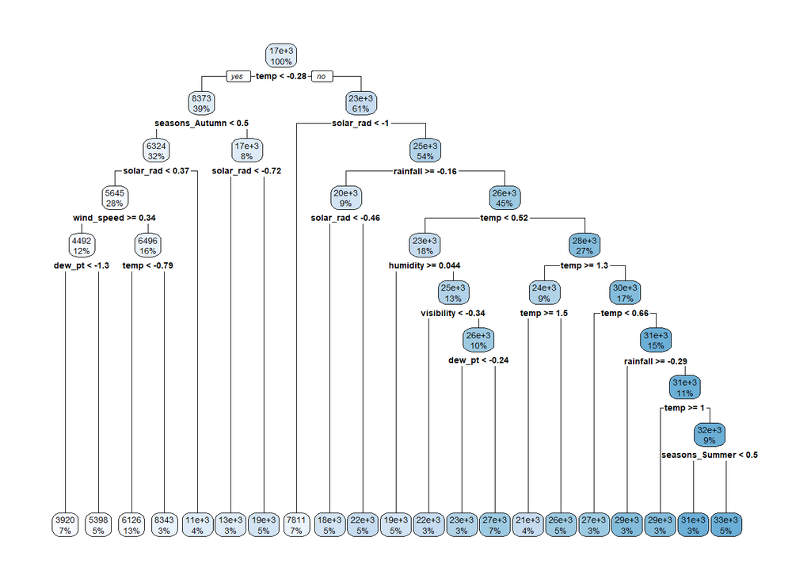

```r
rt_final_model <- extract_workflow(best_rt_test)
rt_final_model |>
  extract_fit_engine() |>
  rpart.plot::rpart.plot(roundint = FALSE)
```

The tree’s numeric weather predictors were standardized using the training data. Their split thresholds therefore represent standardized values rather than original measurement units: zero corresponds to the training mean, while positive and negative values indicate observations above and below that mean. Seasonal dummy variables use zero/one coding. The predicted rental counts shown in the nodes remain in rentals per day.

## Bagged Tree Final Summary:

For the bagged tree model’s final summary, we’ll create a variable importance plot.

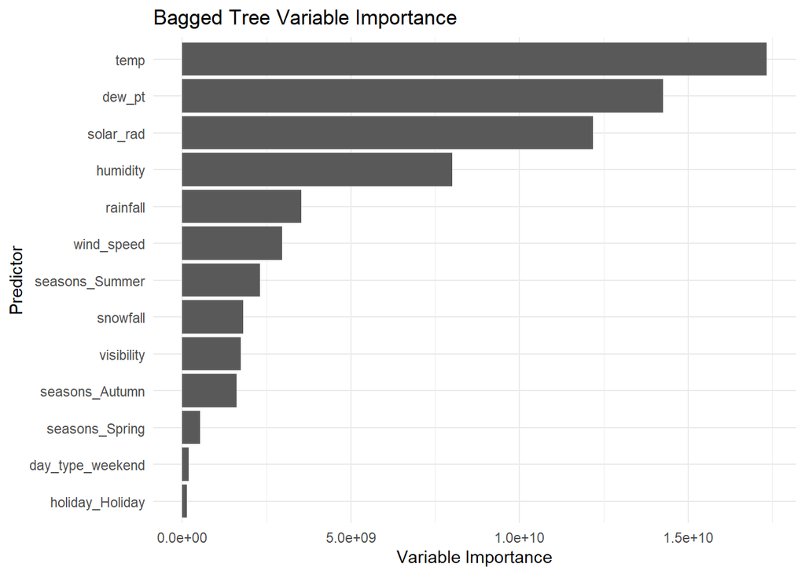

```r
bt_final_model <- best_bt_test |>
  extract_workflow() |>
  extract_fit_engine()

# Get variable importance measures
bt_importance <- baguette::var_imp(bt_final_model)

# Plot variable importance
bt_importance |>
  mutate(term = reorder(term, value)) |>
  ggplot(aes(x = term, y = value)) +
  geom_col() +
  coord_flip() +
  labs(
    title = "Bagged Tree Variable Importance",
    x = "Predictor",
    y = "Variable Importance"
  ) +
  theme_minimal()
```

## Random Forest Variable Importance Plot

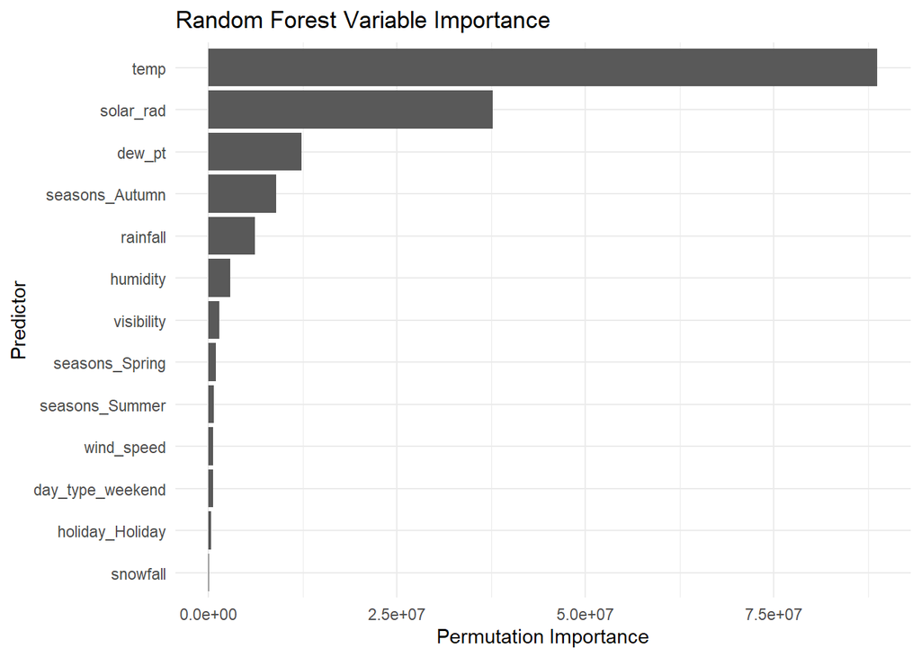

```r
rf_final_model <- best_rf_test |>
  extract_workflow() |>
  extract_fit_engine()

# Extract permutation variable importance
rf_importance <- tibble(
  term = names(rf_final_model$variable.importance),
  value = as.numeric(rf_final_model$variable.importance)
)

# Create the variable importance plot
rf_importance |>
  mutate(term = reorder(term, value)) |>
  ggplot(aes(x = term, y = value)) +
  geom_col() +
  coord_flip() +
  labs(
    title = "Random Forest Variable Importance",
    x = "Predictor",
    y = "Permutation Importance"
  ) +
  theme_minimal()
```

The random forest variable importance plot identifies the predictors that contribute the most to the model’s predictive performance. We use permutation importance, which measures how much the model’s prediction error increases when a predictor’s values are randomly shuffled.

## Fit the Overall Best Model

```r
# Rank models based on test RMSE
model_rankings <- best_fits |>
  filter(.metric == "rmse") |>
  arrange(.estimate) |>
  mutate(rank = row_number()) |>
  select(rank, model, test_rmse = .estimate)

# Display results
knitr::kable(
  model_rankings,
  digits = 2,
  caption = "Final Model Comparison Based on Test RMSE"
)
```

Final Model Comparison Based on Test RMSE

| rank | model | test_rmse |
| --- | --- | --- |
| 1 | Random Forest | 2191.98 |
| 2 | Bagged Tree | 2302.27 |
| 3 | MLR | 3059.35 |
| 4 | Decision Tree | 3499.73 |

```r
# Identify the best model
best_model_name <- model_rankings$model[1]

best_model_name
```

```
[1] "Random Forest"
```

We compare the 4 models using their RMSE values on the held-out test set. Because lower RMSE indicates better predictive performance, we select the model with the lowest RMSE as our overall best model.

```r
# Store finalized workflows for all four model families
candidate_workflows <- list(
  "MLR" = bike_best_mlr_workflow,
  "Decision Tree" = final_rt_wf,
  "Bagged Tree" = final_bt_wf,
  "Random Forest" = final_rf_wf
)

# Select the best workflow
best_overall_workflow <-
  candidate_workflows[[best_model_name]]

# Fit the selected model using the entire dataset
set.seed(558)

best_overall_fit <- best_overall_workflow |>
  fit(data = daily_demand)

# Display the final fitted model
best_overall_fit
```

```
══ Workflow [trained] ══════════════════════════════════════════════════════════
Preprocessor: Recipe
Model: rand_forest()

── Preprocessor ────────────────────────────────────────────────────────────────
5 Recipe Steps

• step_date()
• step_mutate()
• step_rm()
• step_normalize()
• step_dummy()

── Model ───────────────────────────────────────────────────────────────────────
Ranger result

Call:
 ranger::ranger(x = maybe_data_frame(x), y = y, mtry = min_cols(~9L,      x), num.trees = 1000, min.node.size = min_rows(~2L, x), num.threads = 8L,      importance = "permutation", verbose = FALSE, seed = sample.int(10^5,          1))

Type:                             Regression
Number of trees:                  1000
Sample size:                      353
Number of independent variables:  13
Mtry:                             9
Target node size:                 2
Variable importance mode:         permutation
Splitrule:                        variance
OOB prediction error (MSE):       7326780
R squared (OOB):                  0.9258027
```

After we identified our best model, we refit that model using the entire dataset. This means the final model will use all data and not just the training data. The result can be used to predict the bike rental demand for new observations.